## Pôvod dát

Naše dáta o jednotlivých príspevkov z redditu pochádzajú z dvoch datasetov zo stránky keggle.com

1. Posts - https://www.kaggle.com/gpreda/reddit-wallstreetsbets-posts
2. Comments - https://www.kaggle.com/mattpodolak/rwallstreetbets-posts-and-comments

Dáta o cene jednotlivých akcií sa nám podarilo získať z [yahoo finance](https://finance.yahoo.com/), pomocou python balíčka [yfinance](https://pypi.org/project/yfinance/).

### Posts data

```r
df <- read.csv("../data/raw_data/posts.csv")
summary(df)
```

```
##     title               score             id                url
##  Length:47140       Min.   :     0   Length:47140       Length:47140
##  Class :character   1st Qu.:     1   Class :character   Class :character
##  Mode  :character   Median :    32   Mode  :character   Mode  :character
##                     Mean   :  1454
##                     3rd Qu.:   195
##                     Max.   :348241
##    comms_num          created              body            timestamp
##  Min.   :    0.0   Min.   :1.601e+09   Length:47140       Length:47140
##  1st Qu.:    2.0   1st Qu.:1.612e+09   Class :character   Class :character
##  Median :   14.0   Median :1.612e+09   Mode  :character   Mode  :character
##  Mean   :  245.9   Mean   :1.613e+09
##  3rd Qu.:   53.0   3rd Qu.:1.614e+09
##  Max.   :93268.0   Max.   :1.621e+09
```

Dataset o príspevkoch obsauje 47 000 záznamov a má 8 stĺpcov.

- Title - text titulku príspevku
- Score - skóre príspevku na fóre
- Id - identifikátor príspevku
- url - url na príspekov
- comms_num - počet komentárov pod príspevkom
- created - timestamp, kedy bol daný príspevok vytvorený
- body - telo príspevku
- timestamp - timestamp

**Head postov vyzerá nasledovne:**

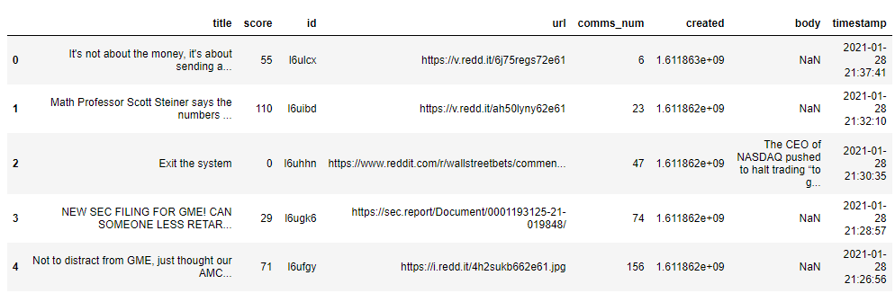

### Comments data

```r
# Zakomentovali sme tento riadok lebo hrozne dlho trva nacitanie 4gb dat...
# namiesto vypisu sme pouzili len screenshot
#df <- read.csv("../data/raw_data/comments.csv")
#summary(df)
print("Odkomentovat")
```

```
## [1] "Odkomentovat"
```

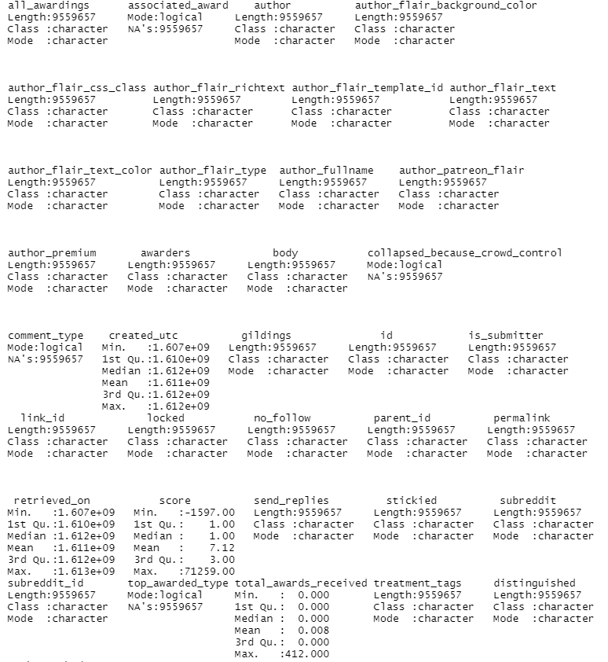

Dataset comments obsahuje 9.5 milióna záznamov pričim má 37 stĺpcov. V nasledujúcej časti opíšeme len stĺpce, s ktorýme sme pracovali pri tvorbe datasetu.

**Použité stĺpce :**

- body - Text komentáru
- parent_id - identifikátor jednotlivých postov
- id - id komentára
- created_utc - čas keby bol daný komentár uverejnený
- score - ohodnotenie daného komentára

## Spracovanie dát

Spracovanie dát je jediná časť projektu, v ktorej sme sa rozhodli využiť Python namiesto Rka a to z dôvodu že v pythone sme skúsenejší a vieme pracovať rýchlejšie a efektívnejšie. Všetky python notebooku sú zverejnené v zložke python_code. Práve efektivita bola potrebná pri takomto množstve dát, ktoré sme museli spracovať. Pre rýchlejšie spracovanie dát sme využili python rozhranie pre [Apache Spark](https://spark.apache.org/) - [pyspark](https://spark.apache.org/docs/latest/api/python/). Taktiež sme využili google cloud computing platformu, na ktorej sme spúštali pySpark aby sme mali k dispozícii väčší výpočtový výkon.

Pre zaujímavosť celé trvanie spracovania dát na google cloud computing platforme trvalo približne 10 hodín.

**Spracovanie dát vyzeralo nasledovne:**

Obrázok znázorňuje grafiky akým cyklom museli prejsť jednotlivé dáta.

[figure not shown]